# Algorithms

`ooacquire` 0.4.2

Pedro J. Aphalo

2023-12-04

## Introduction

In this vignette we will walk through the different steps used in the conversion of raw counts into physical quantities. Different protocols can be used, and not all those implemented are exemplified. The facilities in the package also allow users to implement their own measurement and correction protocols. *It must be, however, always kept in mind that protocols and calibrations go hand in hand:* **For each different measuring protocol or new raw conversion algorithm new calibration multipliers will be required**. In the case of new measurement protocols new calibration data and validation measurements will be needed. However, for new raw data conversion protocols recalculation of new calibration multipliers from existing raw-counts and calibration-lamp data may be enough. In this last case existing validation measurements against other instruments can be reused if available.

## Preliminaries

We start by loading the R packages we will use.

```r
library(ggplot2)
library(ggspectra)
library(photobiology)
library(photobiologyWavebands)
library(ooacquire)
library(magrittr)
```

## Spectral irradiance from a continuous source

Continuous here means that the length of the integration is determined by the integration time setting in the spectrometer rather than the duration of a light burst. There are many ways in which spectral irradiance data can be acquired with an array spectrometer. The most basic approach is to simply 1) measure a light source and subtract the signal from a few pixels in the array that are not exposed to light (electrical dark). This ignores that the dark signal varies to some extent among individual pixels and also ignores stray light. The most common approach is to 2) acquire paired measurements of a light source and with the input optics blocked or the light source switched off. This ignores stray light. In some cases it is best to 3) measure the light source directly, through a filter and completely blocked/switched-off. If a filter suitable for the source is used and a correction algorithm applied it is possible to discount both the dark signal and stray light. Stray light can be usually subtracted only from a certain region of the spectrum. Finally each of these approaches can be combined with 4) the use of multiple integration times to enhance the dynamic range by splicing different spectra for low and high spectral irradiance regions. In all cases it is possible to 5) acquire multiple “scans” or spectra for each measurement using exactly the same settings and average them pixel by pixel to reduce the noise. In many cases this averaging can be done on board the spectrometer or by the software driver on the host computer.

Table 1 lists the measuring protocols supported. Different approaches in general require separate calibrations of the spectrometer. Some approaches are only applicable to specific types of light sources. It is important to understand that acquisition of each of *light*, *dark* and *filter* measurements is done similarly in the different protocols, so if one has used the *“lfd”* protocol to acquire the spectra the analysis as *“ld”* can be done by discarding the measured *filter* spectrum/spectra.

| Protocol | Light | Dark | Filter | HDR |
| --- | --- | --- | --- | --- |
| “l” | yes | no | no | yes/no |
| “ld”, “dl” | yes | yes | no | yes/no |
| “lfd”, “dfl” | yes | yes | yes | yes/no |

By using these protocols we obtain raw counts data from the detector array. These need to be converted into spectral irradiance (energy or photon based). Not all detectors behave similarly. For example, for some types of arrays the dark noise increases only for very long integration times while for others more quickly. To be on the safe side even if not strictly necessary, the default acquisition protocols when multiple integration times are used, these multiple times are applied to light, dark and filter measurements.

In addition to these, additional corrections for the shape of the slit function and stray light are possible and implemented in some correction methods. These of course require characterization and calibration of individual spectrometers in more detail than usually done by manufacturers or most users. The corrections implemented are those described by in Yliantilla et al. (2005) and later modified approaches applicable to different models of spectrometers (Ylianttila, unpublished). Package ‘ooacquire’ thus provides a lot of flexibility but the results achieved will depend on the goodness of the calibration, its traceability and the characteristics of the spectrometer and the light source.

A good array spectrometer has a signal to noise ratio of about 1000, and in the best possible case we can improve this by one order of magnitude to 10000 using some of the approaches implemented. This difference is enough to allow measurement of UV-B radiation in sunlight when the sun is several degrees above the horizon, which are otherwise impossible.

A few things to remember:

- Pixel resolution is usually higher, sometimes a lot higher, than the true optical resolution of the monochromator grid.
- The wavelength step between pixels varies along the array, and by how much depends on the optical configuration.
- Array detectors do not respond linearly to the number of photons, so a linearisation correction is always needed.
- The digitised data for each pixel is a “count”, i.e., an integer number. The maximum count (related to the number of bits) varies, but it is usually not more that 65000.
- In general it is best **not** to apply boxcar smoothing or re-expression to different wavelengths at an early stage or at all.
- Dark noise of the sensor increases with temperature, so some spectrometers have cooled arrays. Spectrometers with no cooling should be shaded from direct sunlight. For accurate measurements spectrometers should be allowed to warm up or cool-down until their temperature is stable.
- Temperature of the spectrometer also affects the wavelength calibration, but how much depends on the design of each spectrometer model.
- Sometimes we know *a priori* which wavelengths are not present in a light source and we can take advantage of this to estimate stray light and or for sanity checks. Say if your reading for UV-C in sunlight at ground level is different from zero, this tells that the measurement is bad. (Not that UV-C is being transmitted through the atmosphere.)
- Know the limitations of the spectrometer and the protocols you use.

## Ylianttila et al.’s (2005) method

I recommend reading the original paper for the details of algorithm and under which conditions it can be used. It roughly corresponds to the method named `ylianttila` in the package, using only *light* and *dark* measurements together with bracketing of the integration time using a factor of 10. This method was originally developed for mesurements of sunbeds. This method requires special characterization of the spectrometer characteristics and a calibration that is good enough to achieve the additional accuracy. The calibration is normally done using the same protocol as for measurements and at a similar temperature. For each type of spectrometer and configuration the validity of the method needs to be demonstrated by comparison to a double monochromator scanning spectrometer.

## Ylianttila’s (unpublished) method for sunlight

Method `ylianttila` uses the `original` stray light correction algorithm for straylight correction developed by Lasse Ylianttila for the Maya 2000 Pro based on Ylianttila et al. (2005). The Maya 2000 Pro suffers from stray light, most notably for sources emmiting IR with wavelengths > 1000 nm. (Early units seem to have worse performance in this respect than more recent ones, even for the same configuration.)

UV-B radiation in sunlight is especially difficult to measure, in general impossible to measure reliably with array spectrometers without a custom sofisticated protocol and correction algorithm. This new method adds a third measurement through a polycarbonate filter (PC). It is crucial to use PC as filter as many other “better” UV blocking filters do not have sufficiently high transmittance in the IR and partly block the stray light. As the PC filter does absorb some visible and IR radiation, about 10-15% for normal incidence, this needs to be compensated as well as any change in incident irradiance between the *light* and *filter* measurements. To achieve this the two measurements are compared at wavelengths in the UV-A1 region and the *filter* measurement rescaled. This works in sunlight or with other continuous spectra but not with discontinuous spectra with low or no radiation in the target region used for rescaling. (When rescaling is not possible a warning is issued and the *filter* measurement not used.)

The correction for stray light has very little if any effect when measuring UV-A1 or visible radiation. In the case of the Maya 2000 Pro it is also very rarely necessary if the light source emits little or no radiation at wavelengths > 1000 nm. So, when measuring narrow band visible or UV radiation from LEDs, the *filter* correction is both unnecessary and impossible to apply. With the Maya 2000 Pro there is one situation where correction for stray light would be needed but not possible with this method: measuring a LED emitting at wavelengths > 950 nm.

## Other methods

I have implemented a variation on Ylianttila’s method to correct for stray light named `full` that differs in the way the ratio used for rescaling the *filter* measurement is computed (the computation is essentially the same as for `original` but removing outliers and limiting the range of values for the ratio). This method should be used only for sunlight or shade light at the Earth surface. This method uses the same characterization and calibration as Ylianttila’s method. For situations were the *light* measurement has been done under irradiance differeing by more than 10% from that during the *filter* measurement, method `original` will perform better.

I have implemented a variation on Ylianttila’s method to correct for stray light named `sun` that differs in that it sets to zero spectral irradiance wavelengths shorter than 290 nm. This method should be used only for sunlight or shadelight at the Earth surface. This method uses the same characterization and calibration as Ylianttila’s method.

Method `simple` uses a simple ad-hoc method to correct for stray light based on a constant value for the PC filter transmittance. It is based on *light*, *filter* and *dark* measurements but no computed rescaling of the *filter* measurement is done except multiplication by a contant. It can be combined with bracketing of integration time even when using a calibration provided by Ocean Optics or acquired with Ocean Optics’ software.

Method `none` does not apply any correction for stray light, is based on a *light* and *dark* measurement. It can be combined with bracketing of integration time even when using a calibration provided by Ocean Optics or acquired with Ocean Optics’ software. It still applies slit function correction if available, but if it is not, and is not combined with bracketing of integration time, it is similar (identical?) to spectral irradiance measured with Ocean Optics software.

## What methods are available

What method can be applied depends on how the spectrometer has been characterized and calibrated. The deatils of each of the methods need to be adjusted to each instrument, and the calibration done using the same corrections or a superset of the corrections used for actual measurements. For a calibration already expressed as multipliers only method `none` is applicable. If the raw counts for the calibration measurements are available for *light*, *filter* and *dark* conditions, calibrations for any of the methods can be constructed. The methods as described include a “tail correction” for the slit function, based on the characterization of the slit function at different wavelengths using a laser. This corrections is most important for sources with narrow peaks such as discharge lamps, and can be skipped if these data are unavailable.

## Examples

We will step through the different stages of the algorithms used, plotting the spectra at each step along the way. We use raw counts data, included in the package, from the measurement of sunlight at ground level with an *Ocean Optics Maya 2000 Pro* array spectrometer. Before the computations walk-through we will describe how the data and metadata are stored. We will also show the use of a high level function that automatically go through all steps needed to convert raw spectrometer counts into irradiance when a correction method and an instrument calibration are supplied.

We will use photon/quantum units throughout for plotting of spectra and display of computed summaries, while printing remains unaffected. We override the default use of energy units by changing the R option with a convenience function.

```r
photon_as_default()
```

### The raw counts data and computed spectral irradiance

Spectral data used in this example were acquired using function `acquire_irrad_interactive()` from this package. This function implements several measurement protocols from which the user can chose. RAW-counts data are returned as a collection of RAW spectra that contains also metadata including a descriptor of the instrument and a record of the instrument settings used. The instrument descriptor contains also the instrument calibration data when available. So irrespective of the approach and number of measurements needed for measuring one irradiance spectrum, all the data and metadata from a measurement are contained in a single R object of class `raw_mspct`. If the calibration data is included in the metadata, then all information needed to compute irradiance is stored in this single object, otherwise the calibration must be available separately.

Function `acquire_irrad_interactive()` returns both spectral irradiance and the raw counts data. For this example, we use the raw counts data. The use of this function to acquire the raw counts data is not a requirement, as data can be also imported from files saved as raw counts using Ocean Optics/Ocean Insight software (*SpectraSuite* or *OceanView*). During import the metadata is read from the file header, while the calibration data has to be imported separately from a separate file or read from the spectrometer memory.

The data contain a measurement of the *light* source, a measurement of the same light source through a polycarbonate *filter* and a reference or *dark* measurement. Each of the three spectra in these collection is a `raw_spct` object.

```r
names(sun001.raw_mspct)
```

```
## [1] "light"  "filter" "dark"
```

The spectrum for the light measurement contains multiple columns, one for each of the different integration times used.

```r
colnames(sun001.raw_mspct[["light"]])
```

```
## [1] "w.length" "counts_1" "counts_2"
```

Summary in addition to displaying the summary for the columns, displays the most important metadata attributes, including the integration times and total measurement times.

```r
summary(sun001.raw_mspct[["light"]])
```

```
## Summary of raw_spct [2,068 x 3] object: anonymous
## Wavelength range 187.82-1117.14 nm, step 0.41-0.48 nm
## Label: light: sun001
## Measured on 2020-06-26 08:44:33.148438 UTC
## Data acquired with 'MayaPro2000' s.n. MAYP11278
## grating 'HC1', slit '010s'
## diffuser 'unknown'
## integ. time (s): 0.131, 1.31
## total time (s): 5.09, 5.22
## counts @ peak (% of max): 91.2
##     w.length         counts_1        counts_2
##  Min.   : 187.8   Min.   : 2187   Min.   : 2114
##  1st Qu.: 431.7   1st Qu.: 8003   1st Qu.:56884
##  Median : 668.7   Median :26402   Median :64000
##  Mean   : 663.3   Mean   :27870   Mean   :53073
##  3rd Qu.: 897.6   3rd Qu.:47836   3rd Qu.:64000
##  Max.   :1117.1   Max.   :58830   Max.   :64000
```

We can explore the structure of the object, to see how data and metadata are stored using `str()` as shown below. We here limit the nesting level so that the output is not too large.

```r
# not run
str(sun001.raw_mspct[["light"]], max.level = 2)
```

```
## raw_spct [2,068 × 3] (S3: raw_spct/generic_spct/tbl_df/tbl/data.frame)
##  $ w.length: num [1:2068] 188 188 189 189 190 ...
##  $ counts_1: num [1:2068] 2306 2222 2193 2195 2515 ...
##  $ counts_2: num [1:2068] 2307 2223 2193 2196 5206 ...
##  - attr(*, "spct.tags")= logi NA
##  - attr(*, "multiple.wl")= num 1
##  - attr(*, "linearized")= int 0
##  - attr(*, "instr.desc")=List of 16
##   ..- attr(*, "class")= chr [1:2] "instr_desc" "list"
##  - attr(*, "instr.settings")=List of 16
##  - attr(*, "when.measured")= POSIXct[1:1], format: "2020-06-26 08:44:33"
##  - attr(*, "where.measured")= tibble [1 × 3] (S3: tbl_df/tbl/data.frame)
##  - attr(*, "what.measured")= chr "light: sun001"
##  - attr(*, "spct.version")= num 2
```

A formatted printout of the instrument setting provides important information. The maximum count value observed relative to the sensor’s maximum allowed counts is specially important for diagnostics of data quality, as a value of 100% indicates clipping while low values, say less than 70% result in decreased dynamic range due to sensor dark noise.

```r
getInstrSettings(sun001.raw_mspct[["light"]])
```

```
## integ. time (s): 0.131, 1.31
## total time (s): 5.09, 5.22
## counts @ peak (% of max): 91.2
```

As with any other R object we access an attribute and use indexing to extract a given metadata value.

```r
attr(sun001.raw_mspct[["light"]], which = "instr.desc")$spectrometer.name
```

```
## [1] "MayaPro2000"
```

In normal use, we calculate irradiance from a raw-counts data set stored as a collection in a `raw_mspct` object using the high-level function `s_irrad_corrected()`. We pass as first argument the object containing the RAW counts and corresponding metadata and the *correction method* to be used in the conversion of the RAW counts into irradiance. In this case we use the modified method developed by Lasse Ylianttila for the *Maya 2000 Pro* spectrometer which suffers more from stray light than the *s2000* spectrometer in Ylianttila et. al (2005) but at the same time has improved sensitivity to UV radiation.

```r
sun001_recalc.spct <-
  s_irrad_corrected(sun001.raw_mspct,
                    correction.method = ooacquire::MAYP11278_ylianttila.mthd)
```

The R object returned by `s_irrad_corrected()` belongs to class `"source_spct"` (defined in package ‘photobiology’) for which summary and plotting methods are available. We first have a quick look at this object. In the output bellow we will notice that the six RAW measurements, three in the light and three in the dark have been used to calculate a single estimate of spectral irradiance. We can also see that the range of wavelengths is narrower as only wavelengths for which calibration data exists have been retained (within 250 to 900 nm in this case). Even though we have set the use of photon based units as the default, the returned spectrum is expressed in energy units as this are used in the calibration data.

```r
summary(sun001_recalc.spct)
```

```
## Summary of source_spct [1,421 x 2] object: sun001_recalc.spct
## Wavelength range 251.16-898.81 nm, step 0.43-0.48 nm
## Label: light: sun001
## Measured on 2020-06-26 08:44:33.148438 UTC
## Time unit 1s
##
##     w.length       s.e.irrad
##  Min.   :251.2   Min.   :-0.002459
##  1st Qu.:418.2   1st Qu.: 0.641692
##  Median :582.2   Median : 0.882086
##  Mean   :579.8   Mean   : 0.808142
##  3rd Qu.:742.5   3rd Qu.: 1.096426
##  Max.   :898.8   Max.   : 1.291537
```

By plotting the spectral irradiance data, either in whole or a range of wavelengths we can better see the shape of the solar spectrum at ground level, and in this example also obtain summaries for the irradiance in different wavebands.

```r
autoplot(sun001_recalc.spct)
```

Using `get_attributes()` we can see that relevant metadata has been copied to the new object.

```r
get_attributes(sun001_recalc.spct)
```

Using a different correction method, that assumes that the measurements are of sunlight at ground level and consequently spectral irradiance for wavelengths shorter than 290 nm should be indistinguishable from zero.

```r
sun001_recalc_sun.spct <-
  s_irrad_corrected(sun001.raw_mspct,
                    correction.method = ooacquire::MAYP11278_sun.mthd)
```

As above, the R object returned by `s_irrad_corrected()` belongs to class `"source_spct"`. As above, the six RAW measurements, three in the light and three in the dark have been used to calculate a single estimate of spectral irradiance.

```r
summary(sun001_recalc_sun.spct)
```

```
## Summary of source_spct [1,421 x 2] object: sun001_recalc_sun.spct
## Wavelength range 251.16-898.81 nm, step 0.43-0.48 nm
## Label: light: sun001
## Measured on 2020-06-26 08:44:33.148438 UTC
## Time unit 1s
##
##     w.length       s.e.irrad
##  Min.   :251.2   Min.   :-0.002447
##  1st Qu.:418.2   1st Qu.: 0.641699
##  Median :582.2   Median : 0.882092
##  Mean   :579.8   Mean   : 0.808150
##  3rd Qu.:742.5   3rd Qu.: 1.096432
##  Max.   :898.8   Max.   : 1.291546
```

By plotting the spectral irradiance data, either in whole or a range of wavelengths we can see that the shape of the spectrum is the same as before but noise in wavelengths < 290 nm has been removed. These data are good so application of either of the two methods gives almost the same resulting spectrum.

```r
autoplot(sun001_recalc_sun.spct)
```

We can also use the same function to obtain counts per second. In other words linearising and dividing the raw counts by the integration time, splicing of spectra obtained using different integration times, applying the corrections inherent to the method selected and the wavelength calibration but not the calibration for the sensitivity of the pixels.

```r
sun001_recalc.cps_spct <-
  s_irrad_corrected(sun001.raw_mspct,
                    correction.method = ooacquire::MAYP11278_ylianttila.mthd,
                    return.cps = TRUE)
```

As the wavelength calibration is available for the whole wavelength range, the returned spectrum expressed as counts per second includes all the wavelengths acquired. In this cases this is an object of class `"cps_spct"`.

```r
summary(sun001_recalc.cps_spct)
```

```
## Summary of cps_spct [2,068 x 2] object: sun001_recalc.cps_spct
## Wavelength range 187.82-1117.14 nm, step 0.41-0.48 nm
## Label: light: sun001
## Measured on 2020-06-26 08:44:33.148438 UTC
## Data acquired with 'MayaPro2000' s.n. MAYP11278
## grating 'HC1', slit '010s'
## diffuser 'unknown'
## integ. time (s): 0.131, 1.31
## total time (s): 5.09, 5.22
## counts @ peak (% of max): 91.2
##     w.length           cps
##  Min.   : 187.8   Min.   : -1261
##  1st Qu.: 431.7   1st Qu.: 40690
##  Median : 668.7   Median :185474
##  Mean   : 663.3   Mean   :201795
##  3rd Qu.: 897.6   3rd Qu.:364123
##  Max.   :1117.1   Max.   :457476
```

By plotting the raw counts expressed as counts per second we can see that the shape of the curve is affected by the varying sensitivity of the spectrometer to photons of different wavelengths.

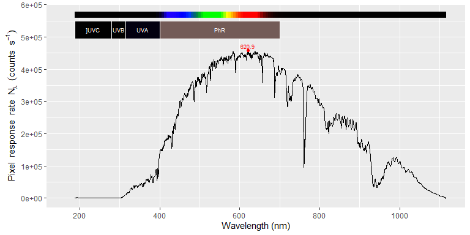

```r
autoplot(sun001_recalc.cps_spct)
```

The instrument descriptor has been copied to

```r
getInstrDesc(sun001_recalc.cps_spct)
```

```
## Data acquired with 'MayaPro2000' s.n. MAYP11278
## grating 'HC1', slit '010s'
## diffuser 'unknown'
```

Looking in more detail into this descriptor with `str()`.

```r
str(getInstrDesc(sun001_recalc.cps_spct))
```

```
## List of 16
##  $ time             : POSIXct[1:1], format: "2016-11-02 16:34:05"
##  $ sr.index         : int 0
##  $ ch.index         : int 0
##  $ spectrometer.name: chr "MayaPro2000"
##  $ spectrometer.sn  : chr "MAYP11278"
##  $ bench.grating    : chr "HC1"
##  $ bench.filter     : chr "000"
##  $ bench.slit       : chr "010s"
##  $ min.integ.time   : int 7200
##  $ max.integ.time   : int 7200000
##  $ max.counts       : int 64000
##  $ wavelengths      : num [1:2068] 188 188 189 189 190 ...
##  $ bad.pixs         : num [1:6] 123 380 388 697 1829 ...
##  $ inst.calib       :List of 9
##   ..$ nl.fun          :function (x)
##   .. ..- attr(*, "srcref")= 'srcref' int [1:8] 25 15 25 44 15 44 575 575
##   .. .. ..- attr(*, "srcfile")=Classes 'srcfilealias', 'srcfile' <environment: 0x000002da77928618>
##   ..$ straylight.coeff: num 0
##   ..$ straylight.slope: num 0
##   ..$ wl.fun          :function (x)
##   ..$ slit.fun        : logi NA
##   ..$ irrad.mult      : num [1:2068] 0 0 0 0 0 0 0 0 0 0 ...
##   ..$ wl.range        : num [1:2] 251 899
##   ..$ start.date      : Date[1:1], format: "2018-04-01"
##   ..$ end.date        : Date[1:1], format: "2021-04-12"
##  $ num.pixs         : num 2068
##  $ num.dark.pixs    : num 20
##  - attr(*, "class")= chr [1:2] "instr_desc" "list"
```

We can in a separate step convert the counts per second data to spectral irradiance by applying the calibration, which in this case is available within `sun001_recalc.cps_spct` stored as a member of the `"intrument.desc"` attribute.

```r
sun001_recalc.source_spct <- cps2irrad(sun001_recalc.cps_spct)
```

In this way we obtain the same irradiance spectrum as before.

```r
summary(sun001_recalc.source_spct)
```

```r
autoplot(sun001_recalc.source_spct)
```

We can plot the calibration multipliers. The sensitivity of the pixels is lowest in the UV region, hence the multipliers are larger. The spectral energy is expressed per detector count (for a given cosine diffuser and fibre used). We obtain an irradiance when we multiply counts per second.

[figure not shown]

```r
wavelengths <- getInstrDesc(sun001_recalc.cps_spct)$wavelengths
multipliers <- getInstrDesc(sun001_recalc.cps_spct)$inst.calib$irrad.mult

calib.spct <- calibration_spct(w.length = wavelengths,
                               irrad.mult = multipliers)

autoplot(calib.spct)
```

### Step-by-step walk through

In this section we will apply one by one the different computation steps staring from RAW spectral data until we obtain spectral irradiance, ´to obtain the same spectrum shown in the figure above. Unless mentioned explicitly all the steps in this walk-through apply to all the methods described above.

We have described in the previous section the structure of the object containing the RAW counts data. As we saw above, measurements consisted in two measurements using two different integration times. In addition to different integration times, the number of “scans” was adjusted so that each of the two spectra contain data for a similar total length of time. This averaging takes place before the data are “seen” by R. The three spectra, *light*, *filter* and *dark* where acquired one after another and using the same settings in the spectrometer.

When dealing with raw detector counts one needs to be aware that the array detector in array spectrometers saturates at a certain number of counts, ranging from 256 to 65000 or more counts (e.g., 64000 counts in the Maya 2000 Pro as shown here and fewer simpler/older models like the USB2000). This information is stored as part of the metadata.

```r
getInstrDesc(sun001.raw_mspct[["light"]])$max.counts
```

```
## [1] 64000
```

If more photons imping on a detector cell/pixel during one integration event (or “scan”) than needed to reach 64000 counts, the reading remains at 64000 counts. This is usually called “signal clipping”, i.e., the tips of peaks are truncated or off scale.

We can find out what integration times have been used from the metadata stored in the same object. In the example spectrum, the shorter integration time used was near optimal, avoiding clipping but still using more the 90% of the pixel counts at the peak. However, the light source has also regions with low emission so we also used a 10 times longer integration time, resulting in clipping of peaks, but making better use of the sensor in the “darker” parts of the spectrum. By changing the number of individual integrations averaged, the total accumulated duration of the measurement was kept at approximately 5 s.

```r
getInstrSettings(sun001.raw_mspct[["light"]])
```

```
## integ. time (s): 0.131, 1.31
## total time (s): 5.09, 5.22
## counts @ peak (% of max): 91.2
```

Plotting the two bracketed spectra shows the effect of using the two different integration times (`counts_1` is the average of 39 integrations each 0.131 s-long, and `counts_2` is the average of 4 integration each 1.31 s-long). Note: The first four pixels in each spectrum are “dark” pixels that are not exposed to light, i.e., the counts are smaller than for other pixels and similar for the short and long integration times. These will show in the plots of the raw spectra as a clear dip in the curve. A similar, but unexpected, dip can be seen at the other end in the infrared.

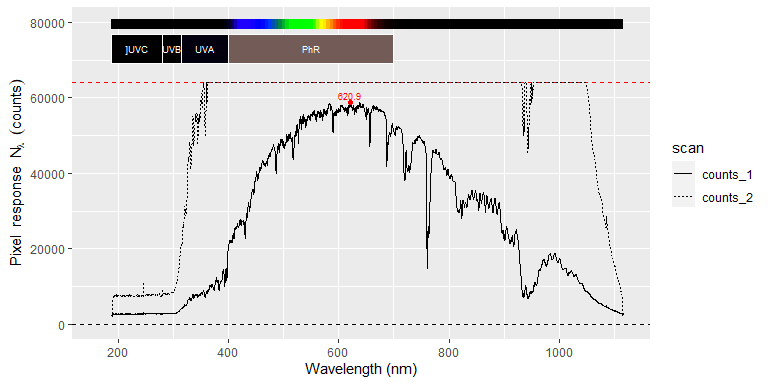

```r
autoplot(sun001.raw_mspct[["light"]])
```

In the figure above, we can see that in addition to clipping, increasing the integration time, at least in some spectrometers, significantly increases the “noise floor” or dark readings. This is also true for the measurements done in darkness. In these spectra, we can also easily see several spikes caused by “hot pixels” in the detector (over-responding pixels). In the figure below we can see the effect of the filter.

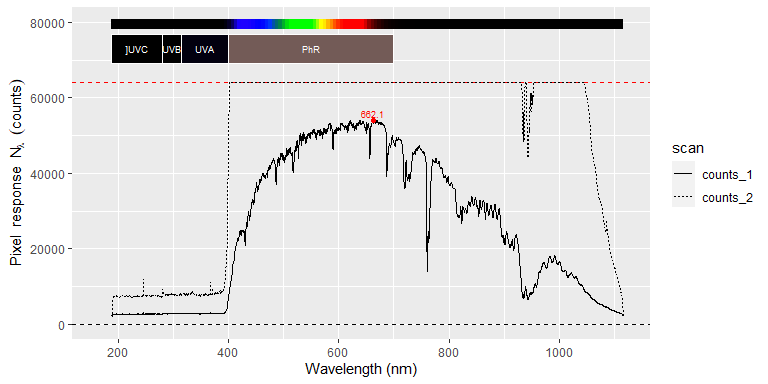

```r
autoplot(sun001.raw_mspct[["filter"]])
```

In this third figure, we have a look at the spectrum measured in darkness. The Maya 2000 Pro spectrometer has the peculiarity that the effect of warming on dark noise depends on wavelength.

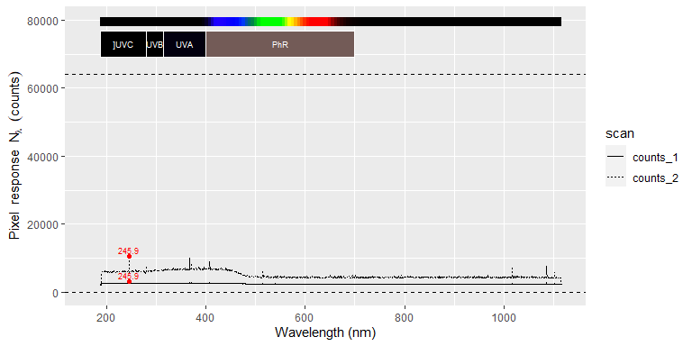

```r
autoplot(sun001.raw_mspct[["dark"]])
```

The **first step** in the processing is to substitute data from known bad pixels by values interpolated from the adjacent fixels. Which pixels are bad is recorded in the calibration data. What this step achieves can be clearly seen by comparing the plots before (see above) and after this step (see below). As in most array spectrometers pixel resolution is better than optical resolution this introduces little error, except possibly in the case of very narrow peaks.

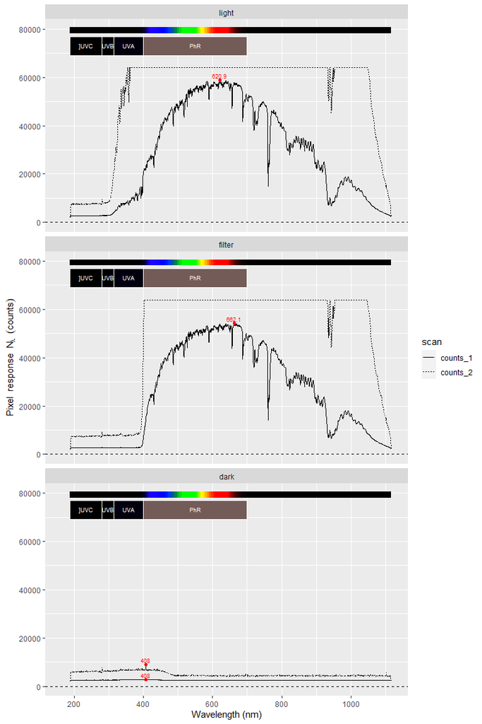

```r
for (m in names(sun001.raw_mspct)) {
  sun001.raw_mspct[[m]] <-
    skip_bad_pixs(sun001.raw_mspct[[m]])
}
autoplot(sun001.raw_mspct, facets = 1)
```

**Note:** When bad-pixel information is not available, automatic despiking can be used instead, but it needs care not to accidentally remove true peaks from the data. (In some types of measurements the spikes appear randomly as they are triggered by cosmic high-energy particles making use of a despiking algorithm a necessity.)

The **second step** is to replace saturated (clipped) pixel data, with the missing data marker `NA`. As `NA` values are not plotted pixels exactly equal to the maximum possible reading disappear from the plots.

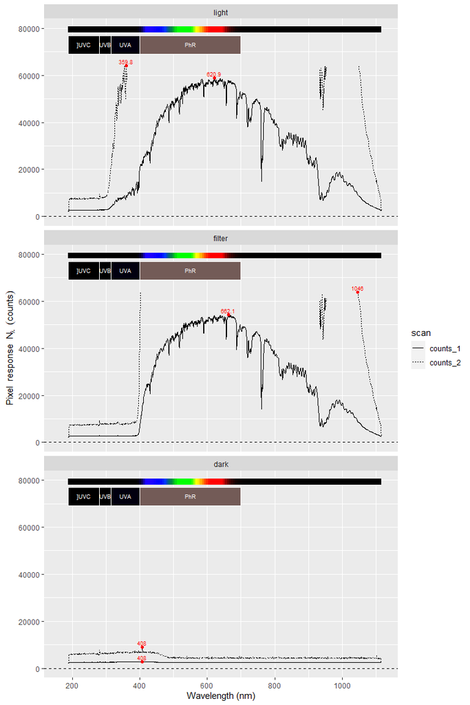

```r
for (m in names(sun001.raw_mspct)) {
  sun001.raw_mspct[[m]] <-
    trim_counts(sun001.raw_mspct[[m]])
}
autoplot(sun001.raw_mspct, facets = 1)
```

An important consideration is that when a pixel *well* fills with electrical charge some of the excess charge migrates to nearby pixels. How many nearby pixels are affected depends on the detector type, but it is at most a few tens of pixels. So in this **third step**, pixels neighbouring those set to `NA` in the second step are also set to `NA`. By default we replace the values from the 10 nearest neighbouring non-saturated pixels also by `NA`.

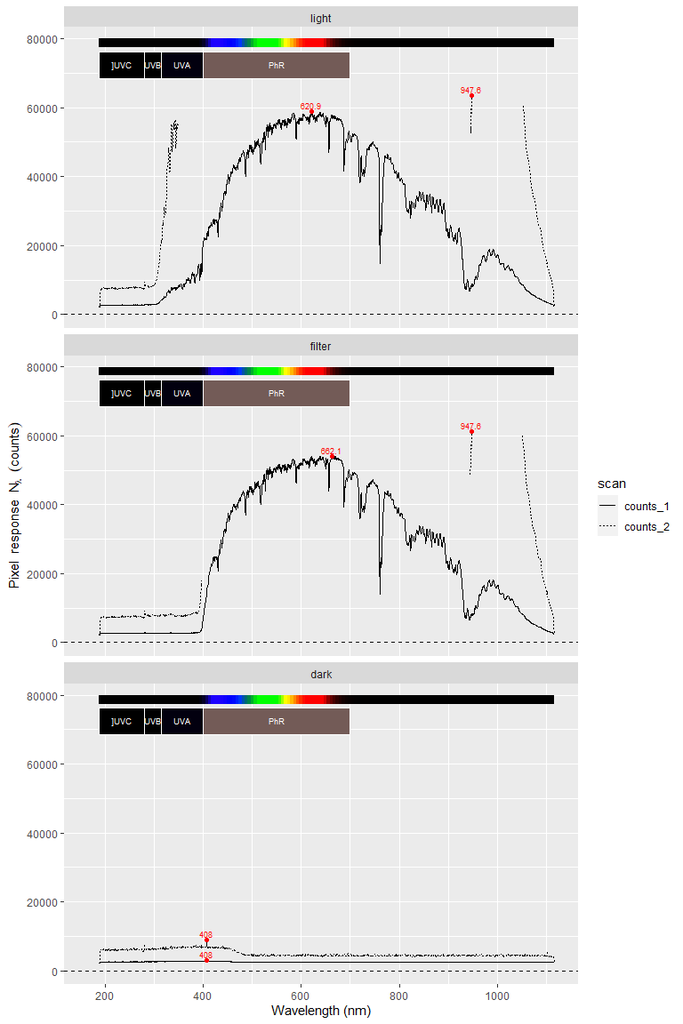

```r
for (m in names(sun001.raw_mspct)) {
  sun001.raw_mspct[[m]] <-
    bleed_nas(sun001.raw_mspct[[m]])
}
autoplot(sun001.raw_mspct, facets = 1)
```

The response of array detectors is not perfectly linear to the number of photons received. Most precisely when the number of counts gets near the maximum value, the sensitivity to additional photons slightly decreases. This is a result of how “full” the sensor wells are, irrespective of the source of the charge (on-target light, stray light or thermal energy). Consequently this correction should be applied before subtraction of the dark reading.

So, the **fourth step** is to apply a linearisation function, in most cases supplied with the instrument and possibly stored in the instrument firmware. This function is part of the calibration data for the instrument that is stored as metadata during acquisition of the spectra. Given that linearization corrects for a decrease in sensitivity at counts approaching the maximum, some values can exceed the maximum instrument counts once corrected (> 64000 in our case).

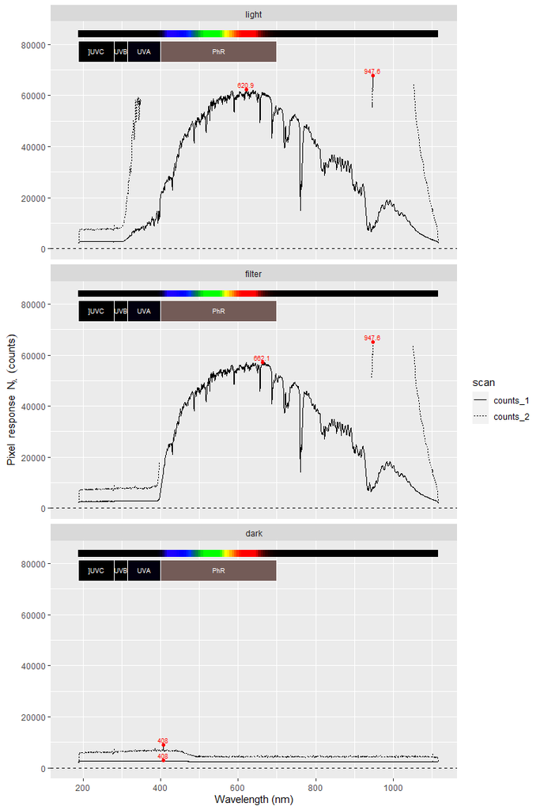

```r
for (m in names(sun001.raw_mspct)) {
  sun001.raw_mspct[[m]] <-
    linearize_counts(sun001.raw_mspct[[m]])
}
autoplot(sun001.raw_mspct, facets = 1)
```

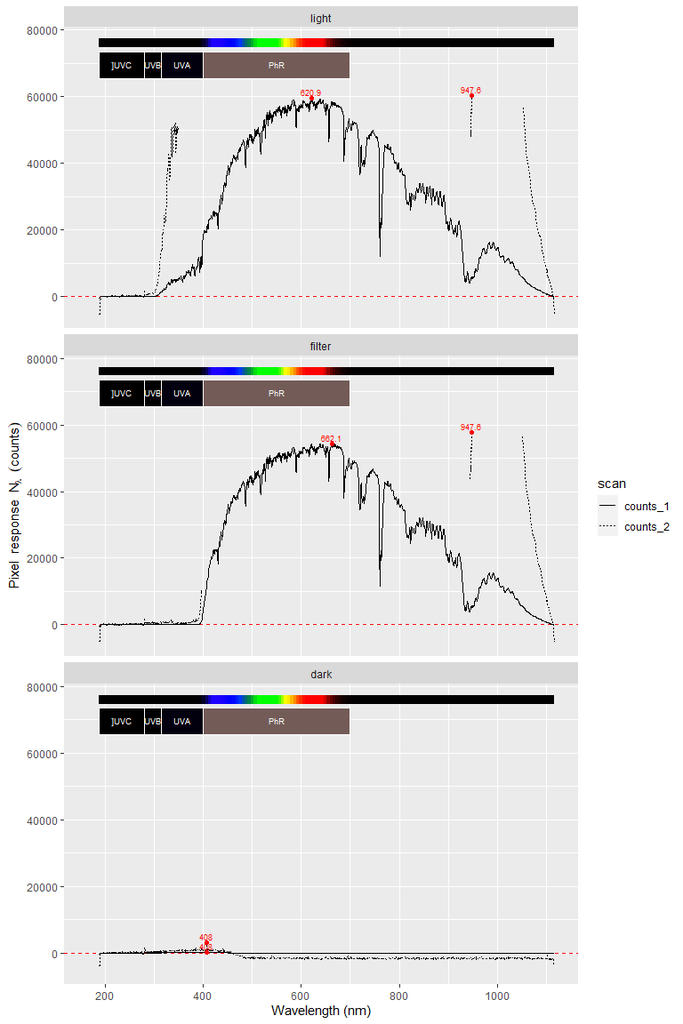

```r
for (m in names(sun001.raw_mspct)) {
  sun001.raw_mspct[[m]] <-
    fshift(sun001.raw_mspct[[m]], range = c(218.5,228.5))
}
autoplot(sun001.raw_mspct, facets = 1)
```

In the last plot above we can see that the correction has resulted in slightly negative values in darkness. If the bump in the noise floor, caused by warming, is consistent among all three measurements, it will cancel out.

```r
sun001.cps_mspct <- raw2cps(sun001.raw_mspct)
```

```r
# autoplot(sun001.cps_mspct, facets = TRUE)
```

The **seventh step** splicing the three pairs of “bracketed” *light*, *filter* and *dark* counts-per-second spectra into three combined spectra.

```r
for (m in names(sun001.cps_mspct)) {
  sun001.cps_mspct[[m]] <-
    merge_cps(sun001.cps_mspct[[m]])
}
```

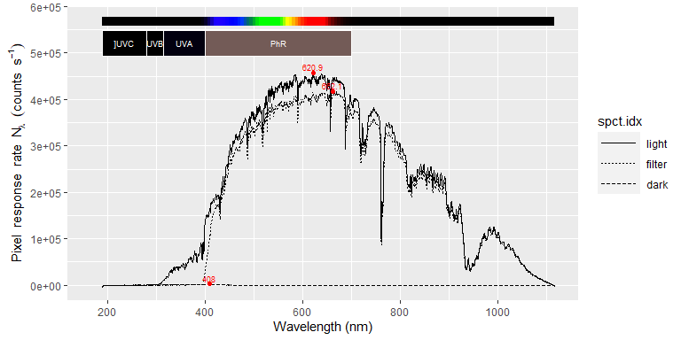

```r
autoplot(sun001.cps_mspct)
```

In the **eighth step** we subtract the dark signal from the *light* and *filter* measurements. This reduces the remaining noise. The filter used has a rather sharp cut-in very close to 400 nm, and blocks UV radiation from entering the spectrometer, so the UV signal remaining after subtracting the dark measurement is the result of light of wavelengths longer than 400 nm “wrongly” striking the UV pixels in the array, i.e., stray light.

In first plot below it looks like there is no stray light present, but zooming-in into the UV-B region we can see that stray light makes a significant contribution to the readings at these short wavelengths.

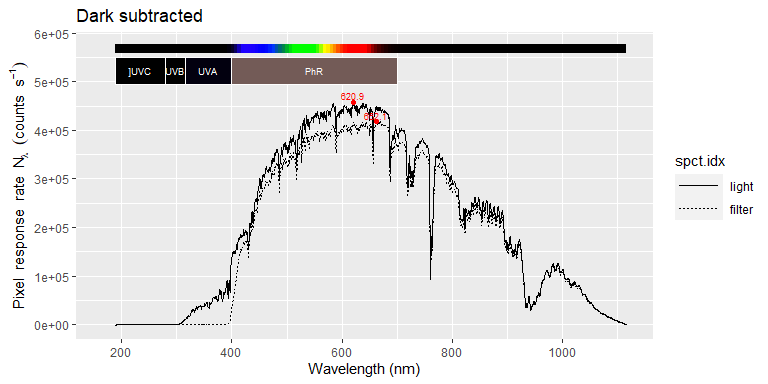

```r
sun001_mdark.cps_mspct <- cps_mspct()

sun001_mdark.cps_mspct[["light"]] <-
  sun001.cps_mspct[["light"]] - sun001.cps_mspct[["dark"]]

sun001_mdark.cps_mspct[["filter"]] <-
  sun001.cps_mspct[["filter"]] - sun001.cps_mspct[["dark"]]

sun001_mdark.cps_mspct[["dark"]] <- NULL

autoplot(sun001_mdark.cps_mspct) + ggtitle("Dark subtracted")
```

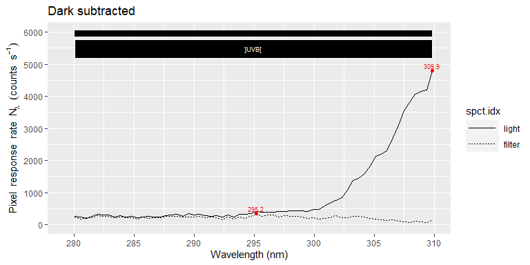

```r
autoplot(clip_wl(sun001_mdark.cps_mspct, range = c(280, 310))) +
  ggtitle("Dark subtracted")
```

To further assess the approximate contribution of stray light to the readings we plot the ratio between these two spectra. Considering that the filter transmits only about 85% of the stray light, we can see that as expected there is only stray light at wavelengths < 293 nm. The methods also estimate absorption of stray light by the filter from the data itself. This estimate also includes and compensates for variation in incident irradiance between *light* and *filter* measurements. (However, it does not compensate for changes in the shape of the spectrum of the incident light between *light* and *filter* measurements.)

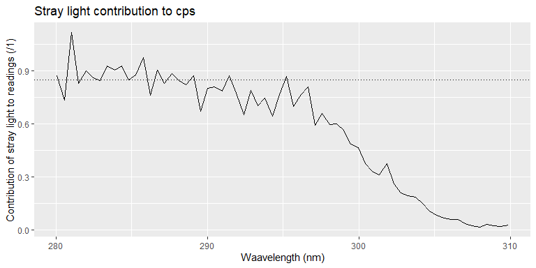

```r
ggplot(clip_wl(sun001_mdark.cps_mspct[["filter"]] /
                   sun001_mdark.cps_mspct[["light"]],
                 range = c(280, 310))) +
  geom_line() +
  geom_hline(yintercept = 0.85, linetype = "dotted") +
  ggtitle("Stray light contribution to cps") +
  labs(y = "Contribution of stray light to readings (/1)",
       x = "Waavelength (nm)")
```

At this point we have a clean counts-per-second spectrum. However, as we have used math operators on the data, we need to restore the metadata.

```r
sun001_mdark.cps_mspct[["light"]] <-
  copy_attributes(sun001.cps_mspct[["light"]],
                  sun001_mdark.cps_mspct[["light"]])

sun001_mdark.cps_mspct[["filter"]] <-
  copy_attributes(sun001.cps_mspct[["filter"]],
                sun001_mdark.cps_mspct[["filter"]])
```

The **ninth step** is to apply the calibration multipliers and any additional instrument specific correction to obtain spectral irradiance stored in a `"source_spct"` object.

We first demonstrate how the *light* measurement with no stray light correction and the *filter* measurement look like when plotted. This *light* spectrum is equivalent to using method `none`. The ratio between the UV-C reading and PAR is close to $3 \times 10^{-4}$ in this case. For sunlight this ratio is usally near $1 \times 10^{-3}$.

```r
sun001.irrad_spct <- cps2irrad(sun001_mdark.cps_mspct[["light"]])
autoplot(sun001.irrad_spct)
sun001_filter.irrad_spct <- cps2irrad(sun001_mdark.cps_mspct[["filter"]])
autoplot(sun001_filter.irrad_spct)
```

In an optional, step we apply smoothing to remove some of the noise from the *light* spectrum, but although the UV-C and UV-B regions look cleaner the value of the summaries remain unchanged and affected by stray light.

```r
sun001.irrad_spct <- smooth_spct(sun001.irrad_spct)
autoplot(sun001.irrad_spct)
```

One key aspect of the more sophisticated methods, is the stray light correction. We here replot the spectrum obtained using method `ylianttila` or `original`. We can see that UV-C is less than $3 \times 10^{-5}$ compared to PAR, and the estimate of UV-B has decreased by 13%. The estimates for UV-A and PAR irradiances remain unchanged.

```r
autoplot(sun001_recalc.spct)
```

We can also apply smoothing to this spectrum, which in this case improves even further the UV-C estimate, which is now less than $5 \times 10^{-6}$ which is an exceptionally good performance, which is rarely achieved for this method, with a usual ratio close to $1 \times 10^{-4}$. So, by using Ylianttila’s method we have improved the signal to noise ratio by more than an order of magnitude.

```r
autoplot(smooth_spct(sun001_recalc.spct))
```

Before continuing with a different example we explain how the stray light correction is done in method `Ylianttila` or `original`. The exact wavelengths used in the algorithm are tuned for each individual spectrometer and are part of the method.

```r
str(MAYP11278_ylianttila.mthd)
```

```
## List of 10
##  $ spectrometer.sn   : chr "MAYP11278"
##  $ stray.light.method: chr "original"
##  $ stray.light.wl    : num [1:2] 218 228
##  $ flt.dark.wl       : num [1:2] 193 210
##  $ flt.ref.wl        : num [1:2] 360 380
##  $ flt.Tfr           : num 1
##  $ inst.dark.pixs    : int [1:3] 2 3 4
##  $ tail.coeffs       : num [1:2] -7.2731 -0.0569
##  $ worker.fun        : chr "MAYP11278_tail_correction"
##  $ trim              : num 0
```

We have three ranges of wavelengths. For sunlight we can assume that pixels for wavelengths in `flt.ref.wl` have received enough photons to be very little affected by stray light. `flt.dark.wl` is the range of wavelengths where we assume the filter is fully opaque. `stray.light.wl` is a wavelength range where we can safely assume (for sunlight) that both *light* and *filter* measurement are just pure stray light; thus, these pixels can be used to rescale the *filter* measurement to compensate for filter transmittance less than one for stray light or changes in stray light caused by a change in incident irardiance. This assumes thay stray light is scattered rather than due to specular reflections within the spectrometer.

**Obviosuly, this filter-based correction, as implemented in correction methos `original` are applicable only to measurements of sunlight or of spectra very similar in shape to sunlight, like natural shade light.**

With a LED source that does not emit in the IR, at least in the case of our Maya 2000 Pro, we do not need to worry about stray light. However, when we measure light sources with a significant emission in the infra-red above 900 nm, stray light becomes a problem. In addition sources with narrow peaks of emission may benefit from deconvolution or correction based on a measurement of the slit function.

### Tungsten halogen lamp

For our instrument, stray light originates mostly in the infra-red and it can be a serious problem when trying to precisely measuring sunlight or incandescent lamps. For this example we use data acquired using a different protocol, which includes three measurements, being the additional one, a measurement through a filter used to estimate stray light in the UV-region. In this case a UV-cut and IR-pass filter (a piece of clear polycarbonate).

The data contains a measurement of the *light* source directly and through a *filter* and a reference *dark* measurement.

```r
names(halogen.raw_mspct)
```

```
## [1] "light"  "filter" "dark"
```

The spectrum for the light measurement contains two columns with RAW-counts data.

```r
names(halogen.raw_mspct[["light"]])
```

```
## [1] "w.length" "counts_1" "counts_2"
```

Summary in addition to displaying the summary for the columns, displays the most important metadata attributes.

```r
summary(halogen.raw_mspct[["light"]])
```

```
## Summary of raw_spct [2,068 x 3] object: anonymous
## Wavelength range 187.82-1117.14 nm, step 0.41-0.48 nm
## Label: Halogen
## Measured on 2017-03-28 11:24:35.664327 UTC
## Data acquired with 'MayaPro2000' s.n. MAYP11278
## grating 'HC1', slit '010s'
## diffuser 'unknown'
## integ. time (s): 1.86, 7.2
## total time (s): 5.58, 7.2
## counts @ peak (% of max): 94.4
##     w.length         counts_1        counts_2
##  Min.   : 187.8   Min.   : 2121   Min.   : 1950
##  1st Qu.: 431.7   1st Qu.: 5316   1st Qu.:14164
##  Median : 668.7   Median :22588   Median :64000
##  Mean   : 663.3   Mean   :25981   Mean   :44225
##  3rd Qu.: 897.6   3rd Qu.:44996   3rd Qu.:64000
##  Max.   :1117.1   Max.   :60728   Max.   :64000
```

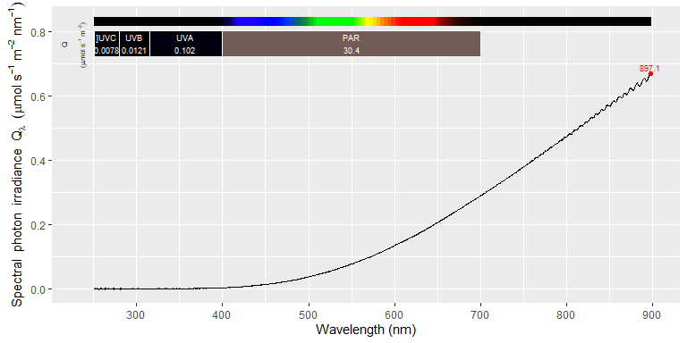

```r
halogen.spct <-
  s_irrad_corrected(halogen.raw_mspct, correction.method= MAYP11278_ylianttila.mthd)
autoplot(halogen.spct)
```

In the example above we called the functions used for each of the steps in the computation individually, saving the intermediate results so as to be able to show the partly processed data at each step. The functions, however, support the use of pipes as they all have as their first parameter the one accepting the R object returned by the previous stage.

```r
halogen.cps_mspct <- cps_mspct()
for (m in names(halogen.raw_mspct)) {
  halogen.raw_mspct[[m]] %>%
    skip_bad_pixs() %>%
    trim_counts() %>%
    bleed_nas() %>%
    linearize_counts() %>%
    fshift(range = c(187.82,189.26)) %>%
    raw2cps() %>%
    merge_cps() -> halogen.cps_mspct[[m]]
}
names(halogen.cps_mspct)
```

```
## [1] "light"  "filter" "dark"
```

We plot the returned spectra, both in full, and the UV region by itself. Please, be aware of the difference in the *y* scale among the plots. By careful comparison of these later plots one can see that the signal for *filter* is larger than for *dark*. As we know from specifications and measurements that the filter used blocks radiation in this region, the difference is due to stray light (radiation of longer wavelengths being detected as ultraviolet).

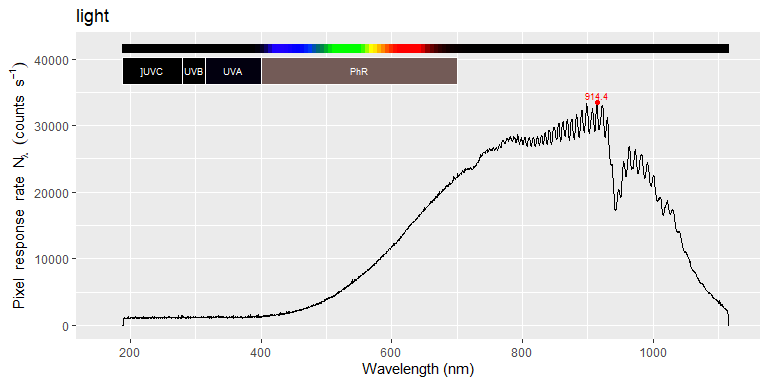

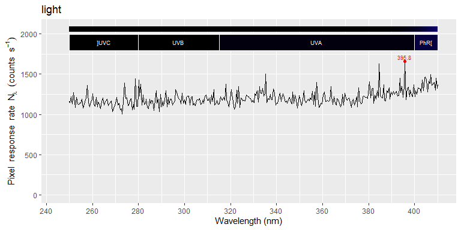

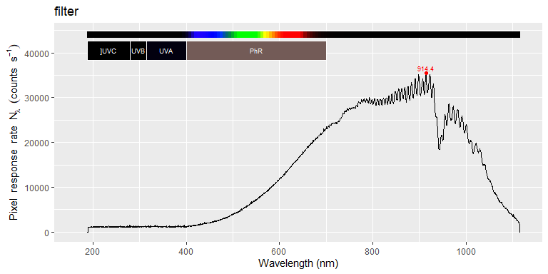

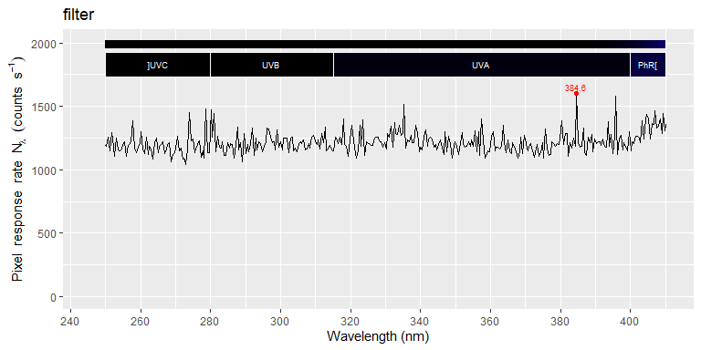

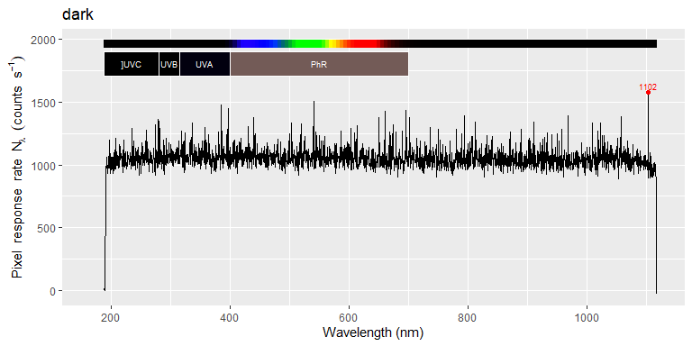

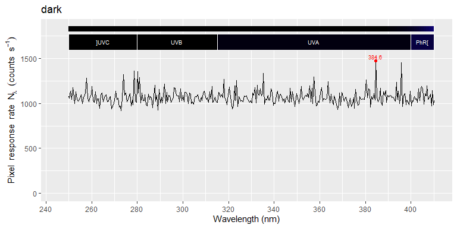

```r
for (m in names(halogen.cps_mspct)) {
  print(autoplot(halogen.cps_mspct[[m]]) + ggtitle(m))
  print(autoplot(halogen.cps_mspct[[m]], range = c(250, 410)) + ggtitle(m))
}
```

In the next step we subtract the *dark* reading from both the *light* and *filter* readings, and copy attributes, including instrument settings and calibration data.

```r
halogen01.cps_mspct <- cps_mspct()
for (m in setdiff(names(halogen.cps_mspct), "dark")) {
  halogen01.cps_mspct[[m]] <- halogen.cps_mspct[[m]] - halogen.cps_mspct[["dark"]]
  halogen01.cps_mspct[[m]] <-
    copy_attributes(halogen.cps_mspct[[m]],
                    halogen01.cps_mspct[[m]],
                    copy.class = FALSE)
}
names(halogen01.cps_mspct)
```

```
## [1] "light"  "filter"
```

The second and fourth plots display in detail the UV region. Be aware of the difference in the *y* scale in the plots

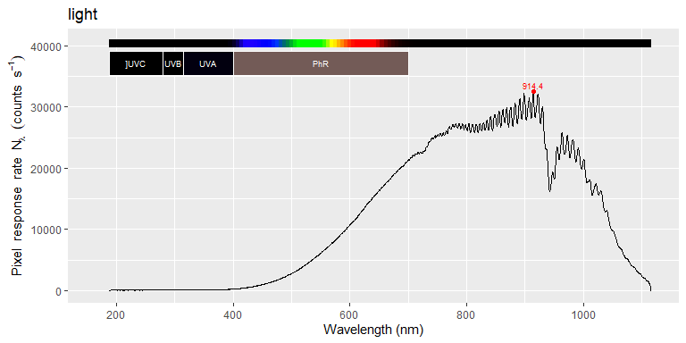

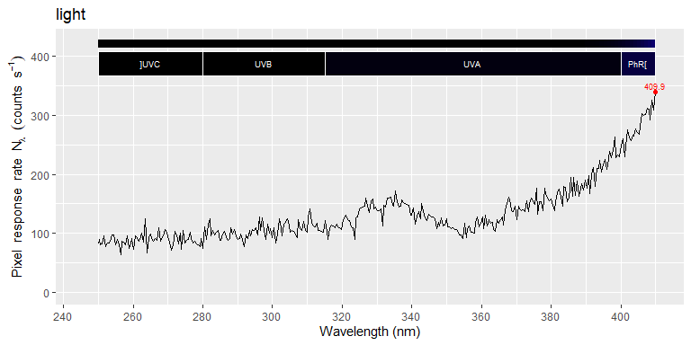

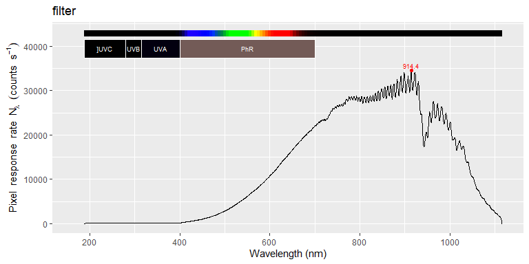

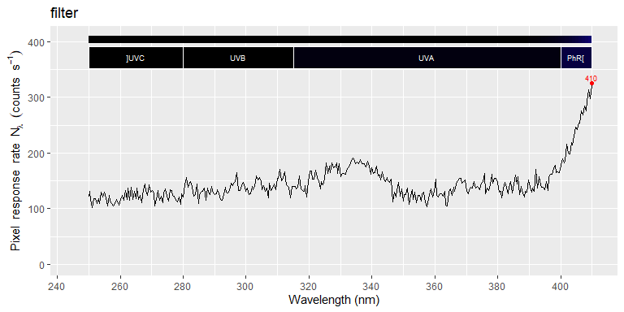

```r
for (m in names(halogen01.cps_mspct)) {
  print(autoplot(halogen01.cps_mspct[[m]]) + ggtitle(m))
  print(autoplot(halogen01.cps_mspct[[m]], range = c(250, 410)) + ggtitle(m))
}
```

```r
halogen_corrected.cps_spct <-
  filter_correction(halogen01.cps_mspct[["light"]],
                    halogen01.cps_mspct[["filter"]],
                    stray.light.method = "original",
                    flt.Tfr = 0.9)
names(halogen_corrected.cps_spct)
```

```
## [1] "w.length" "cps"
```

```r
getTimeUnit(halogen_corrected.cps_spct)
```

```
## [1] "second"
```

The second plot displays in detail the UV region. Be aware of the difference in the *y* scale in the plots

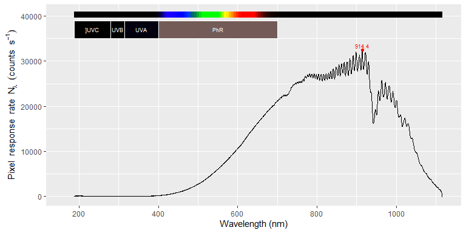

```r
autoplot(halogen_corrected.cps_spct)
```

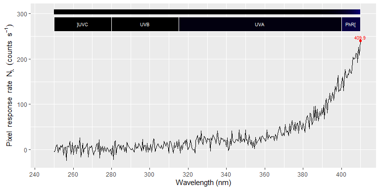

```r
autoplot(halogen_corrected.cps_spct, range = c(250, 410))
```

```r
mean(clip_wl(halogen_corrected.cps_spct, range = c(250, 300))[["cps"]])
```

```
## [1] 2.747068
```

The average counts-per-second remaining after correcting for stray light is very small. In the next step we apply the calibration multipliers to obtain spectral irradiance.

```r
cps2irrad(halogen_corrected.cps_spct) -> halogen.source_spct
names(halogen.source_spct)
```

```
## [1] "w.length"  "s.e.irrad"
```

The spectrum displays some noise at the shortest wavelengths and some interference patterns at the long end. The interference patterns come from the light bulb, but the random noise of increasing amplitude with decreasing wavelength in the UV region is due to the spectrometer.

We can compute some photon ratios, expressed as $mmol\, mol^{-1}$ to diagnose whether the stray light is well controlled.

```r
q_ratio(halogen.source_spct, list(UVC(), UVB(), UVA()), PAR()) * 1e3
```

```
## ]UVC:PAR[q:q]  UVB:PAR[q:q]  UVA:PAR[q:q]
##     0.1925562     0.3494061     3.2901570
## attr(,"radiation.unit")
## [1] "q:q ratio"
```

Smoothing can sometimes help, but it can also introduce bias. It should be used with care and always checking the output.

Using defaults, we get some minor artifacts in the UV region, but preserve the data pattern in the NIR.

```r
halogen_sm0.source_spct <- smooth_spct(halogen.source_spct)
```

```
## 368 possibly 'bad' values in smoothed spectral response
```

The second plot displays in detail the UV region. Be aware of the difference in the *y* scale in the plots

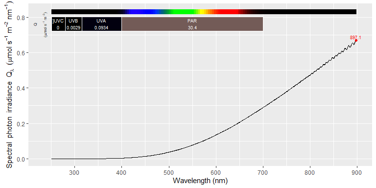

```r
autoplot(halogen_sm0.source_spct)
```

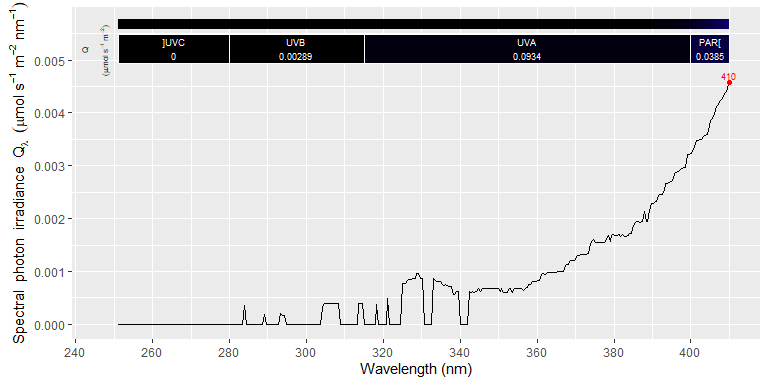

```r
autoplot(halogen_sm0.source_spct, range = c(250, 410))
```

How much difference did smoothing do?

```r
q_ratio(halogen_sm0.source_spct, list(UVC(), UVB(), UVA()), PAR()) * 1e3
```

```
## ]UVC:PAR[q:q]  UVB:PAR[q:q]  UVA:PAR[q:q]
##    0.00000000    0.09519497    3.07102788
## attr(,"radiation.unit")
## [1] "q:q ratio"
```

With overriding the default arguments we better remove random noise and a small “bump” at 320 nm. Setting setting `strength` to `1` instead of `3` smooths the random noise but not this small peak (not shown). In the infra-red most of the wavy pattern is also removed. So, smoothing can be useful, but it can also remove real features, and one needs to decide if these features are of interest or not, based on other sources of information.

```r
halogen_sm.source_spct <- smooth_spct(halogen.source_spct, method = "supsmu", strength = 3)
```

The second plot displays in detail the UV region. Be aware of the difference in the *y* scale in the plots: the ratio between the irradiance at 280 nm and at 900 nm is 1:3500.

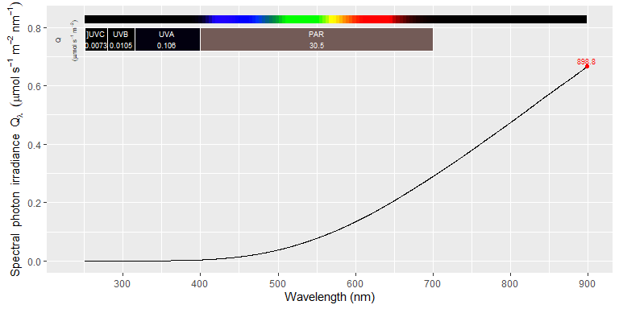

```r
autoplot(halogen_sm.source_spct)
```

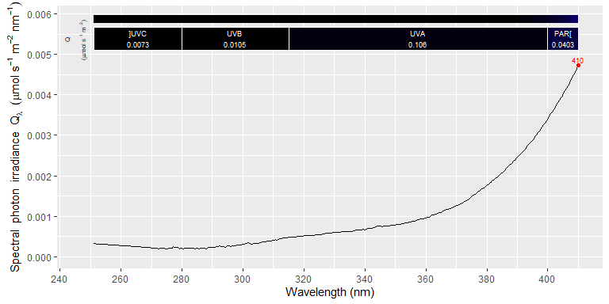

```r
autoplot(halogen_sm.source_spct, range = c(250, 410))
```

How much difference did smoothing do?

```r
q_ratio(halogen_sm.source_spct, list(UVC(), UVB(), UVA()), PAR()) * 1e3
```

```
## ]UVC:PAR[q:q]  UVB:PAR[q:q]  UVA:PAR[q:q]
##     0.2395183     0.3434062     3.4877545
## attr(,"radiation.unit")
## [1] "q:q ratio"
```

## Slit function correction

When measuring spectra containing narrow peaks or steep slopes the shape of the slit function will affect the apparent width of peaks or the apparent steepness of the slope. The slit through which light enters the instrument has a finite width and angle of acceptance for radiation. Consequently, even when measuring true monochromatic radiation from a laser photons will imping on multiple array pixels/wells. The pixel corresponding to the wavelength of the radiation receives the most photons, but the neighbouring pixels receive a decreasing number of photons as the distance from the “correct” target pixel increases. The wider the slit used, the broader the “false” peak observed for monochromatic light. The shape and width of this *slit function* depends not only on the width of the slit but also on other features of the optical bench of the instrument. In array spectrometers the slit function also depends on wavelength as the length of the path from the grating to the detector is not constant.

However, if the slit function is known, it can be used to remove its influence from a measured spectrum, in simpler words it can be used to partly reconstruct the structure of original light source spectrum. In the case of the two examples above, applying this correction would make little difference. In the case of the solar spectrum and discharge lamps this further step improves the estimates for spectral irradiance.

The data contains a measurement of the *light* source and a reference *dark* measurement.

```r
names(xenon_flash.raw_mspct)
```

```
## [1] "light" "dark"
```

The spectrum for the light measurement contains one column with RAW-counts data as no bracketing was used.

```r
names(xenon_flash.raw_mspct[["light"]])
```

```
## [1] "w.length" "counts"
```

Summary in addition to displaying the summary for the columns, displays the most important metadata attributes.

```r
summary(xenon_flash.raw_mspct[["light"]])
```

```
## Summary of raw_spct [2,068 x 2] object: anonymous
## Wavelength range 187.82-1117.14 nm, step 0.41-0.48 nm
## Label: Bare bulb xenon flash
## Measured on 2018-09-13 14:34:06.442208 UTC
## Data acquired with 'MayaPro2000' s.n. MAYP11278
## grating 'HC1', slit '010s'
## diffuser 'unknown'
## integ. time (s): 5.08
## total time (s): 5.08
## counts @ peak (% of max): 91.9
##     w.length          counts
##  Min.   : 187.8   Min.   : 2096
##  1st Qu.: 431.7   1st Qu.: 8150
##  Median : 668.7   Median :13992
##  Mean   : 663.3   Mean   :13795
##  3rd Qu.: 897.6   3rd Qu.:17637
##  Max.   :1117.1   Max.   :57992
```

In the case of these data, the concept of counts-per-second does not apply as the flash discharge is shorter than the integration time, and unknown. The relevant reference is one exposure event and the quantity to estimate is spectral fluence in $J m^{-2}$.

```r
getInstrSettings(xenon_flash.raw_mspct[["light"]])$num.exposures
```

```
## [1] 1
```

```r
xenon_flash.spct <-
  s_irrad_corrected(xenon_flash.raw_mspct, correction.method = MAYP11278_ylianttila.mthd)
getTimeUnit(xenon_flash.spct)
```

```
## [1] "exposure"
```

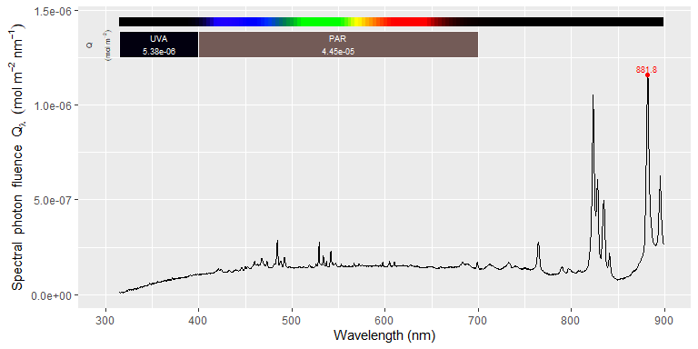

```r
autoplot(xenon_flash.spct, range = c(315, NA))
```

```r
xenon_flash.cps_spct <-
  s_irrad_corrected(xenon_flash.raw_mspct, correction.method= MAYP11278_ylianttila.mthd, return.cps = TRUE)
getTimeUnit(xenon_flash.cps_spct)
```

```
## [1] "exposure"
```

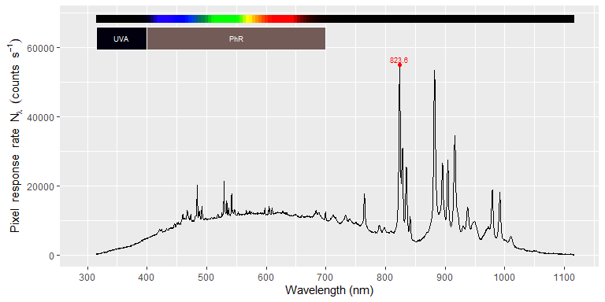

```r
autoplot(xenon_flash.cps_spct, range = c(315, NA))
```

## References

**Ylianttila L, Visuri R, Huurto L, Jokela K**. 2005. Evaluation of a single-monochromator diode array spectroradiometer for sunbed UV-radiation measurements. *Photochemistry and Photobiology* **81**: 333–341.